# iTune Analysis

Adam Santone, PhD

2021-07-04

## Introduction

This analysis was created to extend the original [iTune Device](https://biobuilder.org/lab/itune-device/) lesson from [BioBuilder.org](https://biobuilder.org/). The data were gathered from The [iTune-computational-lab multi-trials](https://dsugat.github.io/BioBuilderModels/iTune-computational-lab-multi-trials_Web.html) simulation.

## Simulation Settings

The simulation was run for each of the following promoter-rbs pairs, known as strains:

- Reference-Reference
- Weak-Weak
- Weak-Medium
- Weak Strong
- Medium-Weak
- Medium-Medium
- Medium-Strong
- Strong-Weak
- Strong-Medium
- Strong-Strong

For each of the ten strains, the following settings were used: * Trial duration: 1200 seconds * Number of Trials: 30 * Model speed: maximum * All other settings: default values

Each simulation run yielded 30 independent b-gal activity data points. For all ten strains, 300 data points were collected.

## Data Import

```r
#import all datasets individually
data_rr<-read_csv("./data/reference_reference.csv")
data_ww<-read_csv("./data/weak_weak.csv")
data_wm<-read_csv("./data/weak_medium.csv")
data_ws<-read_csv("./data/weak_strong.csv")
data_mw<-read_csv("./data/medium_weak.csv")
data_mm<-read_csv("./data/medium_medium.csv")
data_ms<-read_csv("./data/medium_strong.csv")
data_sw<-read_csv("./data/strong_weak.csv")
data_sm<-read_csv("./data/strong_medium.csv")
data_ss<-read_csv("./data/strong_strong.csv")

#combine data
data_main<-tibble(cbind(data_rr[1], data_rr[2],
                        data_ww[2], data_wm[2], data_ws[2],
                        data_mw[2], data_mm[2], data_ms[2],
                        data_sw[2], data_sm[2], data_ss[2]),
                       .name_repair = ~c("trial","rr","ww","wm","ws","mw","mm","ms","sw","sm","ss"))

#pivot the data
data_pivot<-data_main %>% pivot_longer(!trial, names_to = "strain", values_to = "activity")

#force the strains to be an ordered factor
data_pivot$strain <- factor(data_pivot$strain, levels = c("rr","ww","wm","ws","mw","mm","ms","sw","sm","ss"))
```

## Data Visualization

To better understand the data, it’s important to look at the *distribution* of the points within each category. Two important statistics related to the distribution are the *mean* and the *standard deviation*. The mean is the center of the points, or the average, while the standard deviation is the spread of the data points around that center.

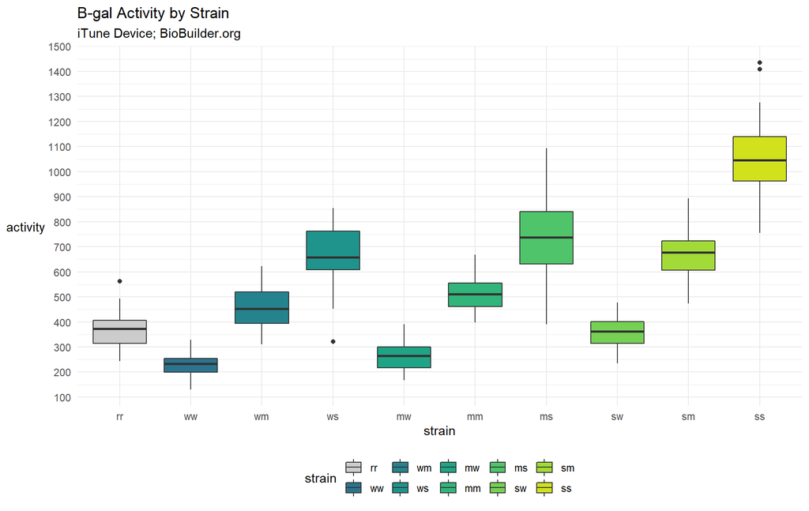

```r
#============================
# data visualization | strain
#============================

#boxplots to show the distribution of data values
ggplot(data_pivot, aes(x=strain, y=activity, fill=strain))+
  geom_boxplot()+
  scale_fill_manual(values=c(rr,ww,wm,ws,mw,mm,ms,sw,sm,ss))+
  scale_y_continuous(breaks=seq(0,1500,100))+
  theme_minimal()+
  theme(legend.position="bottom")+
  labs(title="B-gal Activity by Strain", subtitle="iTune Device; BioBuilder.org")+
  theme(axis.title.y = element_text(angle=0, vjust=0.5))
```

Let’s look at one of these boxes turned sideways and drawn a little bit differently!

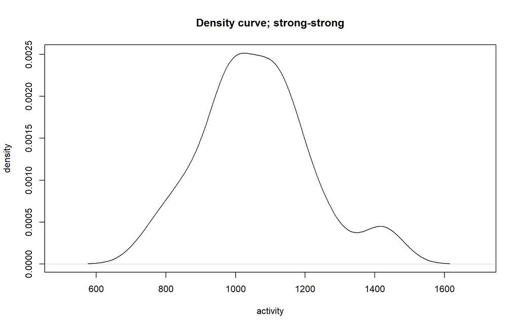

```r
#================================
# data visualization | density
#================================
plot(density(data_main$ss), xlim=c(500,1700), main="Density curve; strong-strong",xlab="activity", ylab="density")
```

Let’s see all of the groups like this! We can split them up or keep them apart.

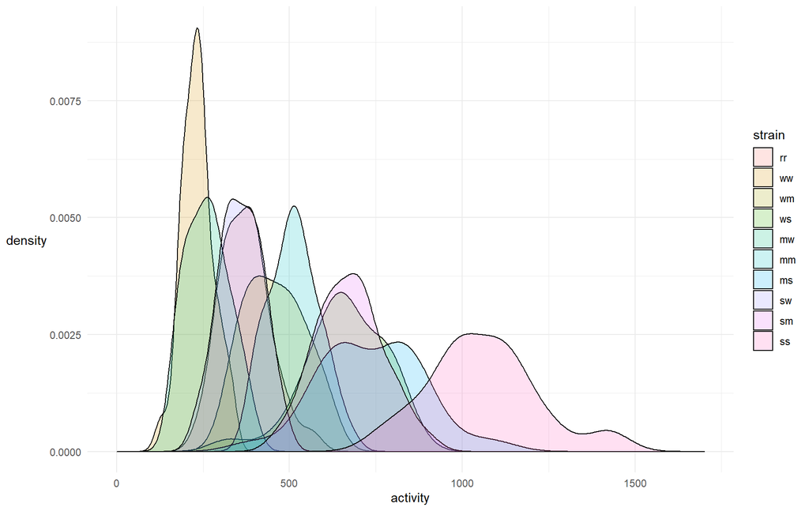

```r
#===================================
# data visualization | density (all)
#===================================
ggplot(data=data_pivot, aes(x=activity, group=strain, fill=strain)) +
    geom_density(alpha=0.2) +
    xlim(0,1700)+
    theme_minimal()+
    theme(axis.title.y = element_text(angle=0, vjust=0.5))
```

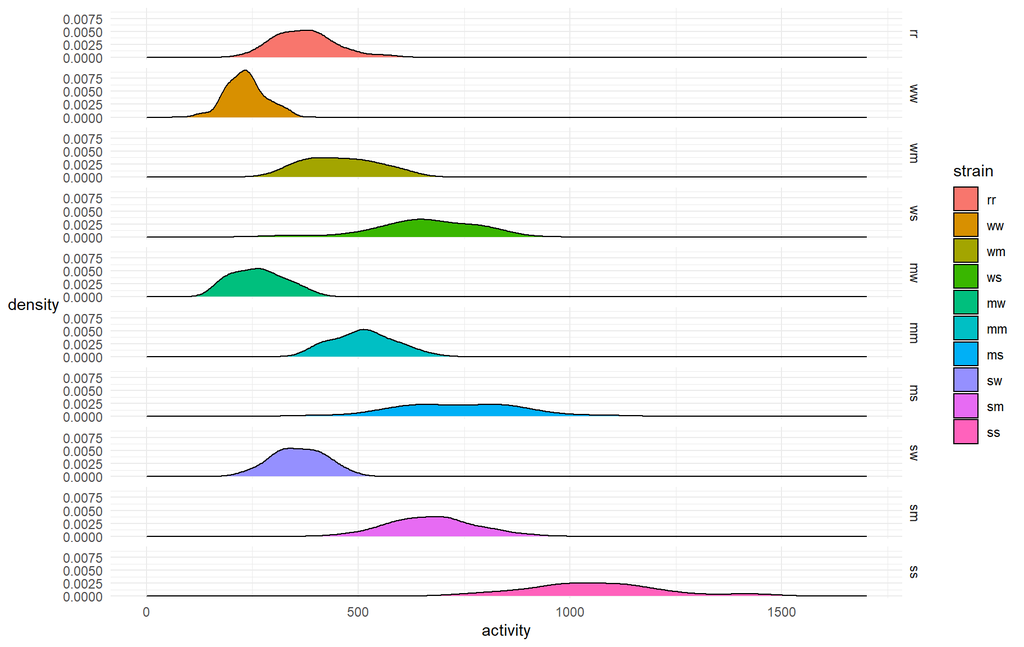

```r
ggplot(data=data_pivot, aes(x=activity, group=strain, fill=strain)) +
    geom_density(alpha=1.0) +
    xlim(0,1700)+
    theme_minimal()+
   facet_grid(strain ~ .)+
    theme(axis.title.y = element_text(angle=0, vjust=0.5))
```

## Analysis of Variance

To determine if there is any statistical difference among these strains, we will use a method that compares the averages of several different groups simultaneously. The idea is to test the hypothesis that all averages are the same. If we find evidence that the hypothesis is not true, we can reject it. The conclusion will then be that there is some difference among the strains’ activity level. This method is called ANOVA which stands for “analysis of variance.”

```r
# ANOVA model
model <- aov(activity ~ strain, data=data_pivot)

# results
summary(model)
```

```
##              Df   Sum Sq Mean Sq F value Pr(>F)
## strain        9 17357630 1928626   199.4 <2e-16 ***
## Residuals   290  2804887    9672
## ---
## Signif. codes:  0 '***' 0.001 '**' 0.01 '*' 0.05 '.' 0.1 ' ' 1
```

```r
#Tukey Honest Significant Differences (pairwise comparisons)
#https://www.rdocumentation.org/packages/stats/versions/3.6.2/topics/TukeyHSD
#hsd<-tibble(TukeyHSD(model)$strain, .name_repair = ~c("difference","lowerCI","upperCI","p-value(adjusted)"))
hsd<-tibble(rownames_to_column(data.frame(TukeyHSD(model)$strain), var = "strain"),
            .name_repair = ~c("strain", "difference","lowerCI","upperCI","pValue"))

#add conditional column
hsd$significant <- ifelse(hsd$pValue <= 0.05,"yes", "no")

#format the table
kable(hsd, caption = "Tukey Honest Significant Differences") %>%
kable_styling(bootstrap_options = c("striped", "hover", "condensed"), full_width = F)
```

Tukey Honest Significant Differences

| strain | difference | lowerCI | upperCI | pValue | significant |
| --- | --- | --- | --- | --- | --- |
| ww-rr | -138.73333 | -219.700237 | -57.76643 | 0.0000045 | yes |
| wm-rr | 85.36667 | 4.399763 | 166.33357 | 0.0295565 | yes |
| ws-rr | 287.06667 | 206.099763 | 368.03357 | 0.0000000 | yes |
| mw-rr | -109.66667 | -190.633570 | -28.69976 | 0.0008904 | yes |
| mm-rr | 139.93333 | 58.966430 | 220.90024 | 0.0000035 | yes |
| ms-rr | 364.26667 | 283.299763 | 445.23357 | 0.0000000 | yes |
| sw-rr | -12.96667 | -93.933570 | 68.00024 | 0.9999641 | no |
| sm-rr | 300.90000 | 219.933097 | 381.86690 | 0.0000000 | yes |
| ss-rr | 686.70000 | 605.733096 | 767.66690 | 0.0000000 | yes |
| wm-ww | 224.10000 | 143.133096 | 305.06690 | 0.0000000 | yes |
| ws-ww | 425.80000 | 344.833097 | 506.76690 | 0.0000000 | yes |
| mw-ww | 29.06667 | -51.900237 | 110.03357 | 0.9795370 | no |
| mm-ww | 278.66667 | 197.699763 | 359.63357 | 0.0000000 | yes |
| ms-ww | 503.00000 | 422.033096 | 583.96690 | 0.0000000 | yes |
| sw-ww | 125.76667 | 44.799763 | 206.73357 | 0.0000540 | yes |
| sm-ww | 439.63333 | 358.666430 | 520.60024 | 0.0000000 | yes |
| ss-ww | 825.43333 | 744.466430 | 906.40024 | 0.0000000 | yes |
| ws-wm | 201.70000 | 120.733097 | 282.66690 | 0.0000000 | yes |
| mw-wm | -195.03333 | -276.000237 | -114.06643 | 0.0000000 | yes |
| mm-wm | 54.56667 | -26.400237 | 135.53357 | 0.4946273 | no |
| ms-wm | 278.90000 | 197.933097 | 359.86690 | 0.0000000 | yes |
| sw-wm | -98.33333 | -179.300237 | -17.36643 | 0.0051335 | yes |
| sm-wm | 215.53333 | 134.566430 | 296.50024 | 0.0000000 | yes |
| ss-wm | 601.33333 | 520.366430 | 682.30024 | 0.0000000 | yes |
| mw-ws | -396.73333 | -477.700237 | -315.76643 | 0.0000000 | yes |
| mm-ws | -147.13333 | -228.100237 | -66.16643 | 0.0000008 | yes |
| ms-ws | 77.20000 | -3.766904 | 158.16690 | 0.0761198 | no |
| sw-ws | -300.03333 | -381.000237 | -219.06643 | 0.0000000 | yes |
| sm-ws | 13.83333 | -67.133570 | 94.80024 | 0.9999378 | no |
| ss-ws | 399.63333 | 318.666430 | 480.60024 | 0.0000000 | yes |
| mm-mw | 249.60000 | 168.633096 | 330.56690 | 0.0000000 | yes |
| ms-mw | 473.93333 | 392.966430 | 554.90024 | 0.0000000 | yes |
| sw-mw | 96.70000 | 15.733097 | 177.66690 | 0.0065005 | yes |
| sm-mw | 410.56667 | 329.599763 | 491.53357 | 0.0000000 | yes |
| ss-mw | 796.36667 | 715.399763 | 877.33357 | 0.0000000 | yes |
| ms-mm | 224.33333 | 143.366430 | 305.30024 | 0.0000000 | yes |
| sw-mm | -152.90000 | -233.866904 | -71.93310 | 0.0000002 | yes |
| sm-mm | 160.96667 | 79.999763 | 241.93357 | 0.0000000 | yes |
| ss-mm | 546.76667 | 465.799763 | 627.73357 | 0.0000000 | yes |
| sw-ms | -377.23333 | -458.200237 | -296.26643 | 0.0000000 | yes |
| sm-ms | -63.36667 | -144.333570 | 17.60024 | 0.2753112 | no |
| ss-ms | 322.43333 | 241.466430 | 403.40024 | 0.0000000 | yes |
| sm-sw | 313.86667 | 232.899763 | 394.83357 | 0.0000000 | yes |
| ss-sw | 699.66667 | 618.699763 | 780.63357 | 0.0000000 | yes |
| ss-sm | 385.80000 | 304.833097 | 466.76690 | 0.0000000 | yes |

### Interpreting the p-value

P-values represent a probability. Refer to [a good source](https://statisticsbyjim.com/hypothesis-testing/interpreting-p-values/) for more information, but briefly, the p-value in an ANOVA test indicate “the probability of observing a (result) that is at least as extreme as your (result) when you assume that the null hypothesis is true.”

Let’s look at this in the context of the iTune activity. Assume for a moment that all strains DO HAVE the same average $\beta$-gal activity. When we conducted our ANOVA, we get to set something called the alpha and we typically will use 0.05 or 5%. If it is true that all strains have the same average activity, then we would expect 5% of our iTune experiments to produce the same (or larger) differences observed here. There are some random effects that can lead to differences between experiments.

As a result, you can think of p-values as “how likely would it be to get what I observed?”

- Large p-values indicate that your results fit nicely with your original assumption (that all means are the same)
- Small p-values indicate your observations do not fit nicely and are “statistically significant”

## Data Summary

Finally, a table summarizing the calculated means and standard deviations of the data is shown. Although the data were generated and these values were more or less known already, this information is presented as another option for data analysis and would typically be included from real-world observations.

```r
#=========================
# data summary
#=========================
#create tables

#sorted by strain
table_strain<-data_pivot %>% group_by(strain) %>% summarise(mean = mean(activity), sd = sd(activity)) %>% arrange(strain)

#sorted by bGal activity
table_activity<-data_pivot %>% group_by(strain) %>% summarise(mean = mean(activity), sd = sd(activity)) %>% arrange(mean)

#format the table
kable(table_strain, caption = "B-gal Activity by Strain") %>%
kable_styling(bootstrap_options = c("striped", "hover", "condensed"), full_width = F)
```

B-gal Activity by Strain

| strain | mean | sd |
| --- | --- | --- |
| rr | 372.8000 | 70.21858 |
| ww | 234.0667 | 45.31950 |
| wm | 458.1667 | 85.49615 |
| ws | 659.8667 | 116.33950 |
| mw | 263.1333 | 61.71890 |
| mm | 512.7333 | 70.94677 |
| ms | 737.0667 | 147.24199 |
| sw | 359.8333 | 61.14713 |
| sm | 673.7000 | 96.85437 |
| ss | 1059.5000 | 158.89831 |

```r
#format the table
kable(table_activity, caption = "B-gal Activity by Average Activity") %>%
kable_styling(bootstrap_options = c("striped", "hover", "condensed"), full_width = F)
```

B-gal Activity by Average Activity

| strain | mean | sd |
| --- | --- | --- |
| ww | 234.0667 | 45.31950 |
| mw | 263.1333 | 61.71890 |
| sw | 359.8333 | 61.14713 |
| rr | 372.8000 | 70.21858 |
| wm | 458.1667 | 85.49615 |
| mm | 512.7333 | 70.94677 |
| ws | 659.8667 | 116.33950 |
| sm | 673.7000 | 96.85437 |
| ms | 737.0667 | 147.24199 |
| ss | 1059.5000 | 158.89831 |